# ROC_curve

Анастасия Горшкова

2024-11-01

# Проверяем датасет на наличие выбросов и пропущенных значений

```r
df <- readxl::read_xlsx("data/trauma.xlsx") %>%
    mutate(
      across(c(id, Death), as.factor),
      Height = as.numeric(sub('"', '', Height)) * 2.54 / 100, # convert height to m
      Weight = Weight / 2.2,
           Hb = na_if(Hb, 0),
      across(where(is.character), as.factor)
           )

summary(df)
```

```
##        id                     Name          Sex           Age
##  1      :   1   Robert Burke    :   2   Female:384   Min.   :18.00
##  2      :   1   Aaron Brandon   :   1   Male  :640   1st Qu.:29.00
##  3      :   1   Aaron Bullington:   1                Median :41.00
##  4      :   1   Aaron Dickinson :   1                Mean   :40.94
##  5      :   1   Aaron Eddy      :   1                3rd Qu.:53.00
##  6      :   1   Aaron Kelly     :   1                Max.   :64.00
##  (Other):1018   (Other)         :1017
##      Height          Weight            SBP             DBP
##  Min.   :1.621   Min.   : 60.59   Min.   : 90.0   Min.   : 58.00
##  1st Qu.:1.770   1st Qu.: 82.58   1st Qu.:106.0   1st Qu.: 78.00
##  Median :1.849   Median : 88.14   Median :110.0   Median : 84.00
##  Mean   :1.840   Mean   : 87.97   Mean   :110.8   Mean   : 84.78
##  3rd Qu.:1.908   3rd Qu.: 93.38   3rd Qu.:116.0   3rd Qu.: 90.00
##  Max.   :2.029   Max.   :115.05   Max.   :134.0   Max.   :110.00
##
##       FOUR             GSC               Hb        Death
##  Min.   : 0.000   Min.   : 3.000   Min.   : 9.40   0:615
##  1st Qu.: 7.000   1st Qu.: 6.000   1st Qu.:12.10   1:409
##  Median : 9.000   Median : 8.000   Median :13.10
##  Mean   : 8.853   Mean   : 7.785   Mean   :13.01
##  3rd Qu.:11.000   3rd Qu.:10.000   3rd Qu.:14.00
##  Max.   :16.000   Max.   :14.000   Max.   :16.20
##                                    NA's   :16
```

# 1. Описательная статистика для переменных

Дополнительно рассчитайте, у какого количества пациентов и в каком проценте случаев у пациентов был снижен уровень гемоглобина? Используйте следующие референтные значения (Мужчины: 13.5–16 г/дл, Женщины: 12–14 г/дл).

```r
statistics <- list(
      `Количество субъектов` = ~length(.x) %>% as.character(),
#    `Количество (есть данные)` = ~sum(!is.na(.x)) %>% as.character(),
#      `Нет данных` = ~sum(is.na(.x)) %>% as.character(),
      `Ср. знач.` = ~ifelse(sum(!is.na(.x)) == 0, "Н/П*", mean(.x, na.rm = TRUE) %>% round(2) %>% as.character()),
      `Станд. отклон.` = ~ifelse(sum(!is.na(.x)) < 3, "Н/П*", sd(.x, na.rm = TRUE) %>% round(2) %>% as.character()),
      `95% ДИ для среднего` = ~ifelse(sum(!is.na(.x)) < 3, "Н/П*", paste0(ci_min(.x) %>% round(2), " - ", ci_max(.x) %>% round(2))),
      `мин. - макс.` = ~ifelse(sum(!is.na(.x)) == 0, "Н/П*", paste0(min(.x, na.rm = TRUE) %>% round(2), " - ", max(.x, na.rm = TRUE) %>% round(2))),
      `Медиана` = ~ifelse(sum(!is.na(.x)) == 0, "Н/П*", median(.x, na.rm = TRUE) %>% round(2) %>% as.character()),
      `Q1 - Q3` = ~ifelse(sum(!is.na(.x)) == 0, "Н/П*", paste0(quantile(.x, 0.25, na.rm = TRUE) %>% round(2), " - ", quantile(.x, 0.75, na.rm = TRUE) %>% round(2)))
)
```

```r
ci_min <- function(x) {
  x <- na.omit(x)
  se <- sd(x) / sqrt(length(x))
  error_margin <- qt(0.975, df = length(x) - 1) * se # t-критическое значение для 95%
  ci_min <- mean(x) - error_margin
  return(ci_min)
}

ci_max <- function(x) {
  x <- na.omit(x)
  se <- sd(x) / sqrt(length(x))
  error_margin <- qt(0.975, df = length(x) - 1) * se # t-критическое значение для 95%
  ci_max <- mean(x) + error_margin
  return(ci_max)
}
```

Описательная статистика для количественных переменных

```r
df %>%
  select(where(is.numeric)) %>%
  summarize(across(everything(), statistics)) %>%
  pivot_longer(cols = everything(), names_to = "name", values_to = "value") %>%
  separate(name, into = c("variable", "statistics"), sep = "_") %>%
  pivot_wider(names_from = statistics, values_from = value) %>%
  flextable() %>%
  theme_box() %>%
  align(align = "center", part = "all") %>%
  merge_v("variable")
```

| variable | Количество субъектов | Ср. знач. | Станд. отклон. | 95% ДИ для среднего | мин. - макс. | Медиана | Q1 - Q3 |
| --- | --- | --- | --- | --- | --- | --- | --- |
| Age | 1024 | 40.94 | 13.66 | 40.11 - 41.78 | 18 - 64 | 41 | 29 - 53 |
| Height | 1024 | 1.84 | 0.08 | 1.83 - 1.84 | 1.62 - 2.03 | 1.85 | 1.77 - 1.91 |
| Weight | 1024 | 87.97 | 8.29 | 87.46 - 88.47 | 60.59 - 115.05 | 88.14 | 82.58 - 93.38 |
| SBP | 1024 | 110.78 | 7.45 | 110.32 - 111.23 | 90 - 134 | 110 | 106 - 116 |
| DBP | 1024 | 84.78 | 8.42 | 84.27 - 85.3 | 58 - 110 | 84 | 78 - 90 |
| FOUR | 1024 | 8.85 | 3.01 | 8.67 - 9.04 | 0 - 16 | 9 | 7 - 11 |
| GSC | 1024 | 7.79 | 2.69 | 7.62 - 7.95 | 3 - 14 | 8 | 6 - 10 |
| Hb | 1024 | 13.01 | 1.28 | 12.93 - 13.09 | 9.4 - 16.2 | 13.1 | 12.1 - 14 |

Описательная статистика для факторных переменных

```r
df %>%
  select(-id, -Name) %>%
  select(where(is.factor)) %>%
  pivot_longer(cols = everything(), names_to = "Variable", values_to = "Value") %>%
  group_by(Variable, Value) %>%
  summarise(n = n(), .groups = 'drop') %>%
  group_by(Variable) %>%
  mutate(`%` = paste0(round((n / sum(n)) * 100, 2), " %") ) %>%
  ungroup() %>%
  select(Variable, Value, n, `%`) %>%
  arrange(Variable, Value) %>%
  flextable() %>%
  theme_box() %>%
  align(align = "center", part = "all") %>%
  merge_v("Variable")
```

| Variable | Value | n | % |
| --- | --- | --- | --- |
| Death | 0 | 615 | 60.06 % |
|  | 1 | 409 | 39.94 % |
| Sex | Female | 384 | 37.5 % |
|  | Male | 640 | 62.5 % |

Расчёт количества и процента пациентов с пониженным уровнем гемоглобина

```r
low_Hb_men <- 13.5
low_Hb_women <- 12


df %>%
  mutate(
    low_Hb = case_when(
      Sex == "Male" & Hb < low_Hb_men ~ TRUE,
      Sex == "Female" & Hb < low_Hb_women ~ TRUE,
      TRUE ~ FALSE
    )
  ) %>%
  summarize(
    total_patients = n(),
    low_Hb_count = sum(low_Hb),
    low_Hb_percent = (low_Hb_count / total_patients) * 100
  )
```

```
## # A tibble: 1 × 3
##   total_patients low_Hb_count low_Hb_percent
##            <int>        <int>          <dbl>
## 1           1024          458           44.7
```

Результат: из 1024 пациентов у 458 из них наблюдается сниженный гемоглобин, что составляет 44,73%

# Расчет ИМТ пациентов

Добавим параметр BMI в таблицу.

```r
df$BMI <- round(df$Weight / ((df$Height)^2), 2)
summary(df)
```

```
##        id                     Name          Sex           Age
##  1      :   1   Robert Burke    :   2   Female:384   Min.   :18.00
##  2      :   1   Aaron Brandon   :   1   Male  :640   1st Qu.:29.00
##  3      :   1   Aaron Bullington:   1                Median :41.00
##  4      :   1   Aaron Dickinson :   1                Mean   :40.94
##  5      :   1   Aaron Eddy      :   1                3rd Qu.:53.00
##  6      :   1   Aaron Kelly     :   1                Max.   :64.00
##  (Other):1018   (Other)         :1017
##      Height          Weight            SBP             DBP
##  Min.   :1.621   Min.   : 60.59   Min.   : 90.0   Min.   : 58.00
##  1st Qu.:1.770   1st Qu.: 82.58   1st Qu.:106.0   1st Qu.: 78.00
##  Median :1.849   Median : 88.14   Median :110.0   Median : 84.00
##  Mean   :1.840   Mean   : 87.97   Mean   :110.8   Mean   : 84.78
##  3rd Qu.:1.908   3rd Qu.: 93.38   3rd Qu.:116.0   3rd Qu.: 90.00
##  Max.   :2.029   Max.   :115.05   Max.   :134.0   Max.   :110.00
##
##       FOUR             GSC               Hb        Death        BMI
##  Min.   : 0.000   Min.   : 3.000   Min.   : 9.40   0:615   Min.   :18.47
##  1st Qu.: 7.000   1st Qu.: 6.000   1st Qu.:12.10   1:409   1st Qu.:24.30
##  Median : 9.000   Median : 8.000   Median :13.10           Median :25.96
##  Mean   : 8.853   Mean   : 7.785   Mean   :13.01           Mean   :26.06
##  3rd Qu.:11.000   3rd Qu.:10.000   3rd Qu.:14.00           3rd Qu.:27.77
##  Max.   :16.000   Max.   :14.000   Max.   :16.20           Max.   :34.82
##                                    NA's   :16
```

Каков был средний (M (SD)) уровень ИМТ у пациентов, включённых в исследование?

```r
sd_bmi <- sd(df$BMI)
print(sd_bmi)
```

```
## [1] 2.571623
```

Cредний (M (SD)) уровень ИМТ у пациентов, включённых в исследование, был 26.06 (+-2.57)

Какая доля пациентов имела ожирение (ИМТ> 30)?

```r
df %>%
  mutate(
    obese = case_when(
      BMI > 30 ~ TRUE,
      TRUE ~ FALSE
    )
  ) %>%
  summarize(
    total_patients = n(),
    obese_count = sum(obese),
    obese_percent = (obese_count / total_patients) * 100
  )
```

```
## # A tibble: 1 × 3
##   total_patients obese_count obese_percent
##            <int>       <int>         <dbl>
## 1           1024          71          6.93
```

6.93% участников исследования страдали ожирением

# ROC-кривая для предсказания летального исхода в течение 24 часов по переменной, характеризующей уровень гемоглобина?

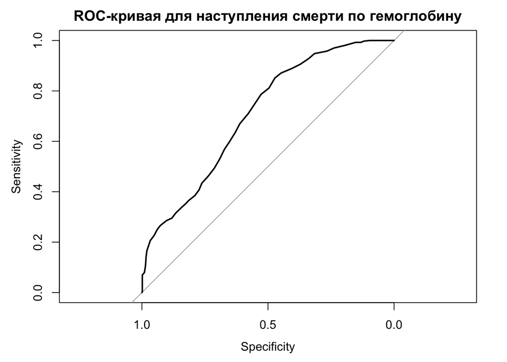

```r
roc_curve_HB <- roc(df$Death, df$Hb)
plot(roc_curve_HB, main = "ROC-кривая для наступления смерти по гемоглобину")
```

Кривая расположена над линией y=x, что означает, что предсказательная сила показателя гемоглобина выше, чем ожидается от рандомного показателя

Чтобы судить о том, насколько этот показатель хорош, необходимо посчитать AUC

Чему равна площадь под ROC-кривой, которую вы построили в вопросе 3? Чему равен 95% двусторонний ДИ для площади под ROC-кривой, которую вы построили в вопросе 3?

```r
auc(roc_curve_HB)
```

```
## Area under the curve: 0.7078
```

Площадь под кривой равна 0.7078

```r
ci.auc(roc_curve_HB)
```

```
## 95% CI: 0.6763-0.7392 (DeLong)
```

Довеерительный интервал равен 0.6763-0.7392

AUC около 70% это достаточно хорошо, это означает, что у показателя Hb приемлемо хороший диагностический потенциал

# ROC-анализ для показателя шкала комы Глазго

Проведите ROC-анализ и определите, какое пороговое значение является оптимальным для предсказания летального исхода в течение 24 часов по шкале комы Глазго. Какой чувствительностью и специфичностью обладает данный порог?

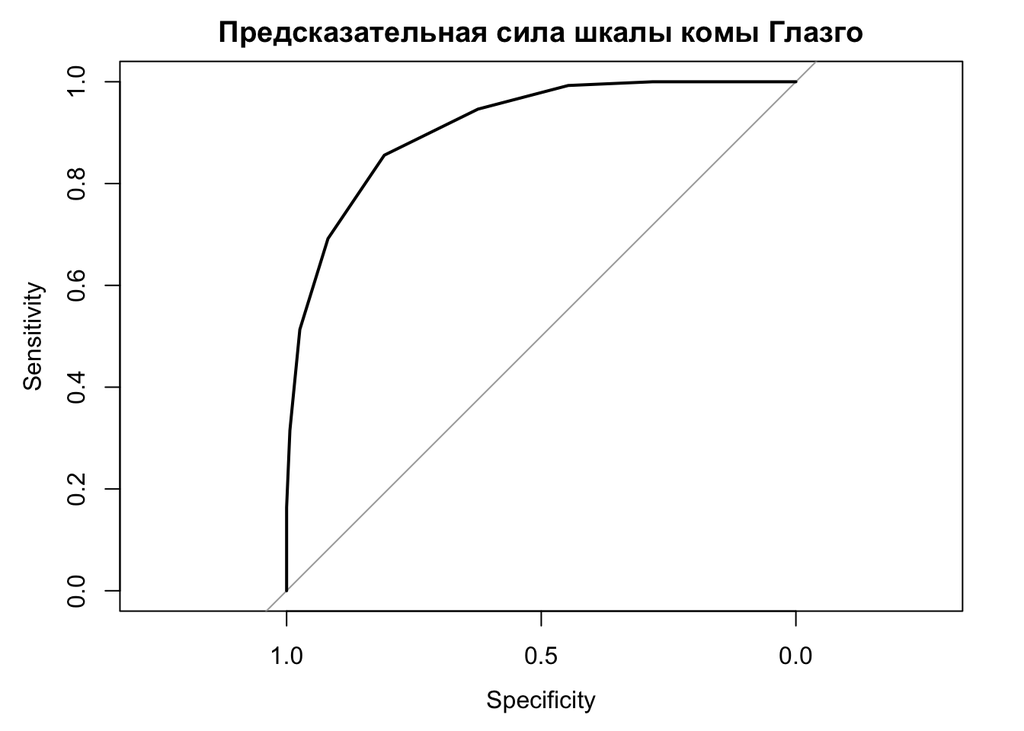

```r
roc_curve_GSC <- roc(df$Death, df$GSC, quiet = TRUE)
plot(roc_curve_GSC, main = "Предсказательная сила шкалы комы Глазго")
```

```r
auc(roc_curve_GSC)
```

```
## Area under the curve: 0.9124
```

```r
ci.auc(roc_curve_GSC)
```

```
## 95% CI: 0.8959-0.9289 (DeLong)
```

AUC = 0.9124, CI: 0.8959-0.9289

Значит, что шкала Глазго - очень хороший и надежный показатель с высокой предсказательной способностью

Оптимальный порог подбирали так, чтобы максимизировать показатель Youden’s J statistic (максимизирует сумму чувствительности и специфичности): J = Sensitivity + Specificity − 1

```r
optimal_coords <- coords(roc_curve_GSC, "best", ret = c("threshold", "sensitivity", "specificity"), best.method = "youden")
print(optimal_coords)
```

```
##   threshold sensitivity specificity
## 1       7.5   0.8557457   0.8081301
```

Анализ показал, что оптимальный порог = 7.5

# РОС-анализ для всех количественных переменных

Какая из количественных переменных в датасете (включая рассчитанный вами ранее ИМТ) обладает наибольшей площадью под ROC-кривой? Как вы можете интерпретировать это знание? Какая количественная переменная имеет наименьшую площадь?

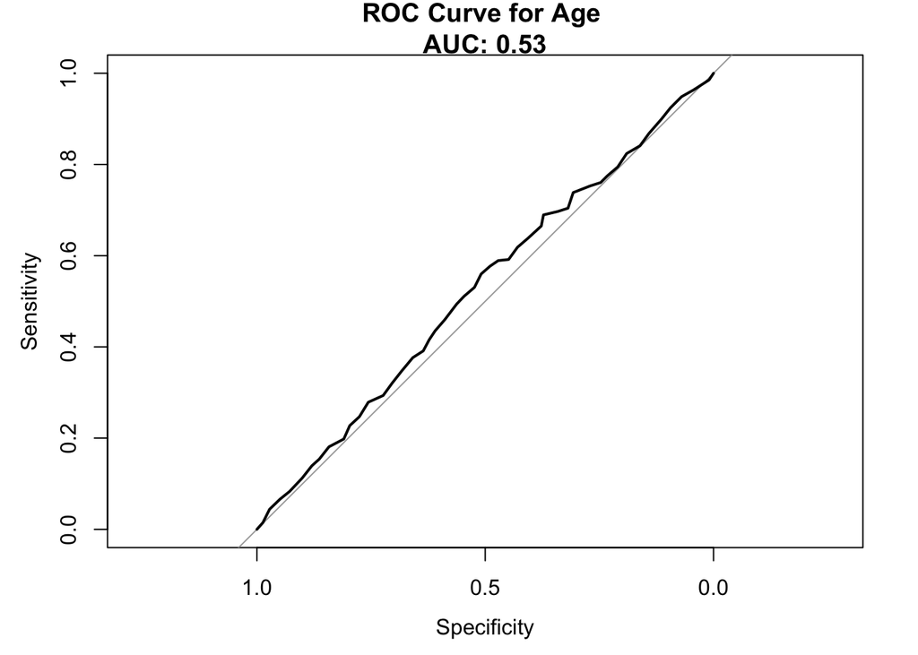

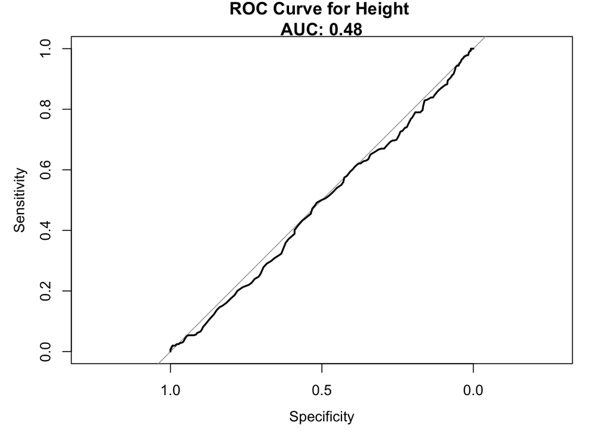

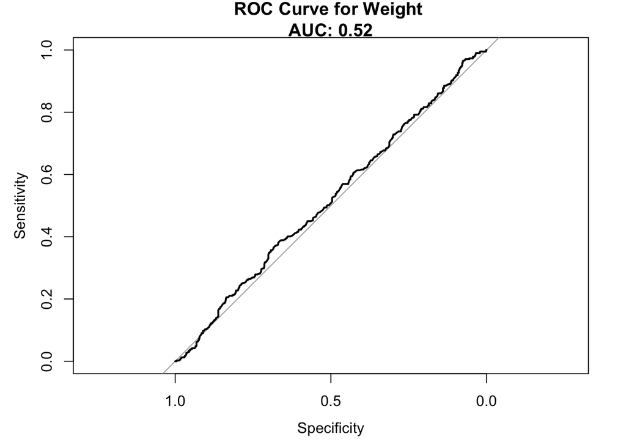

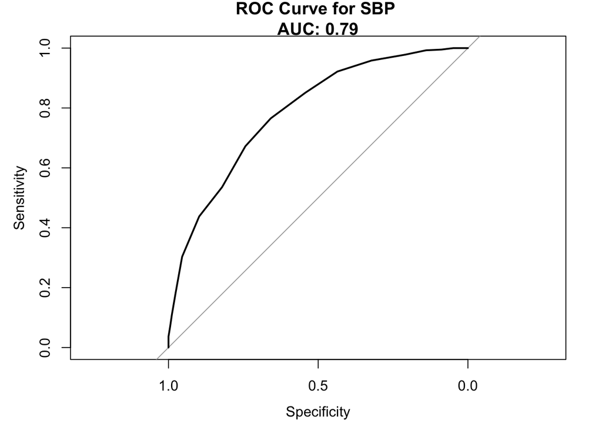

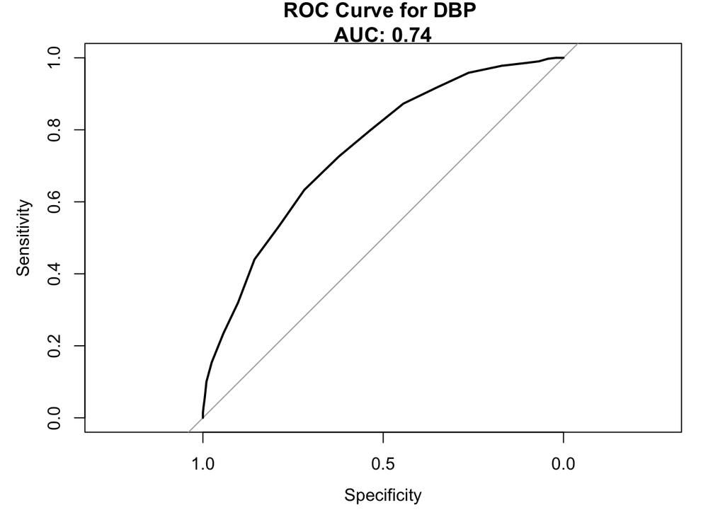

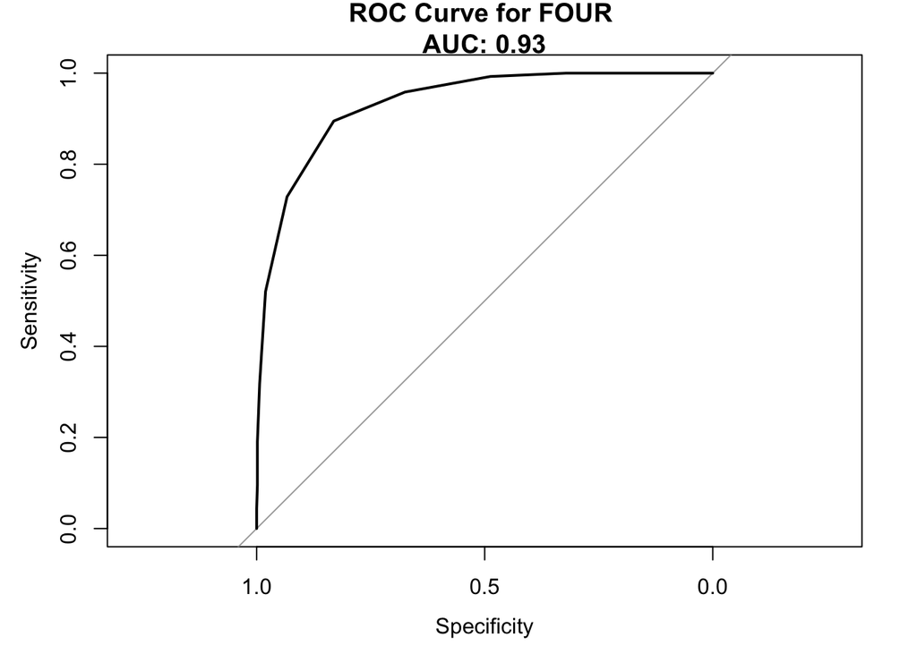

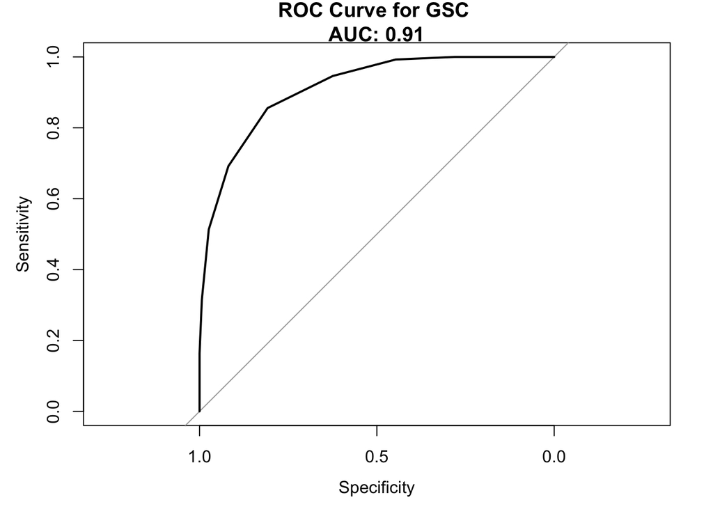

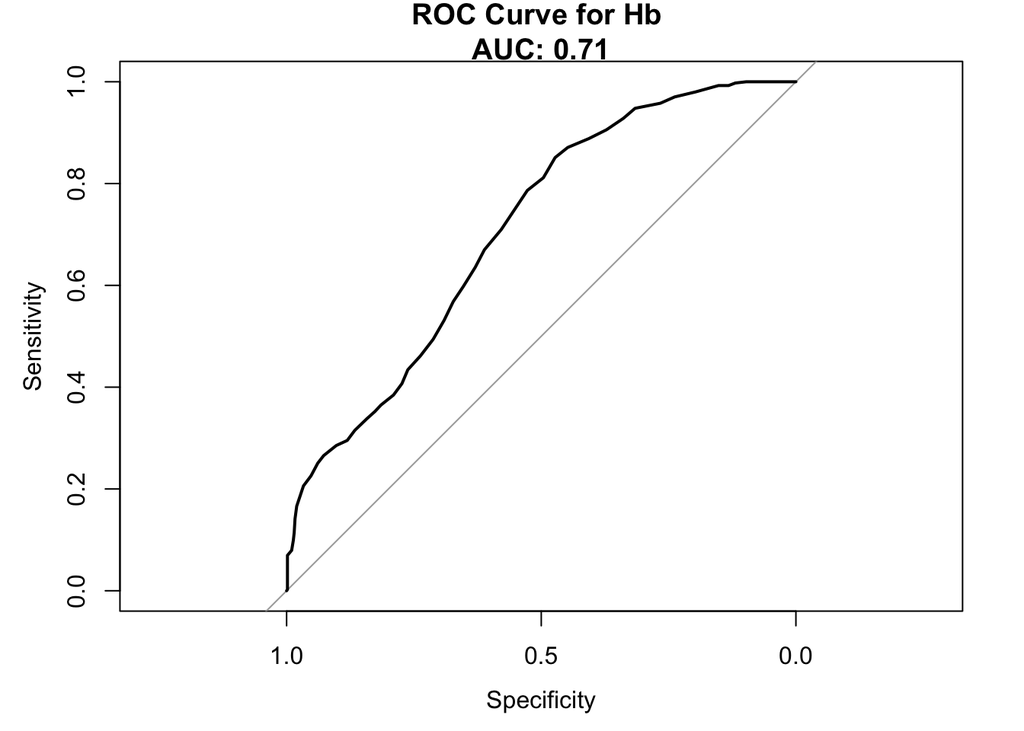

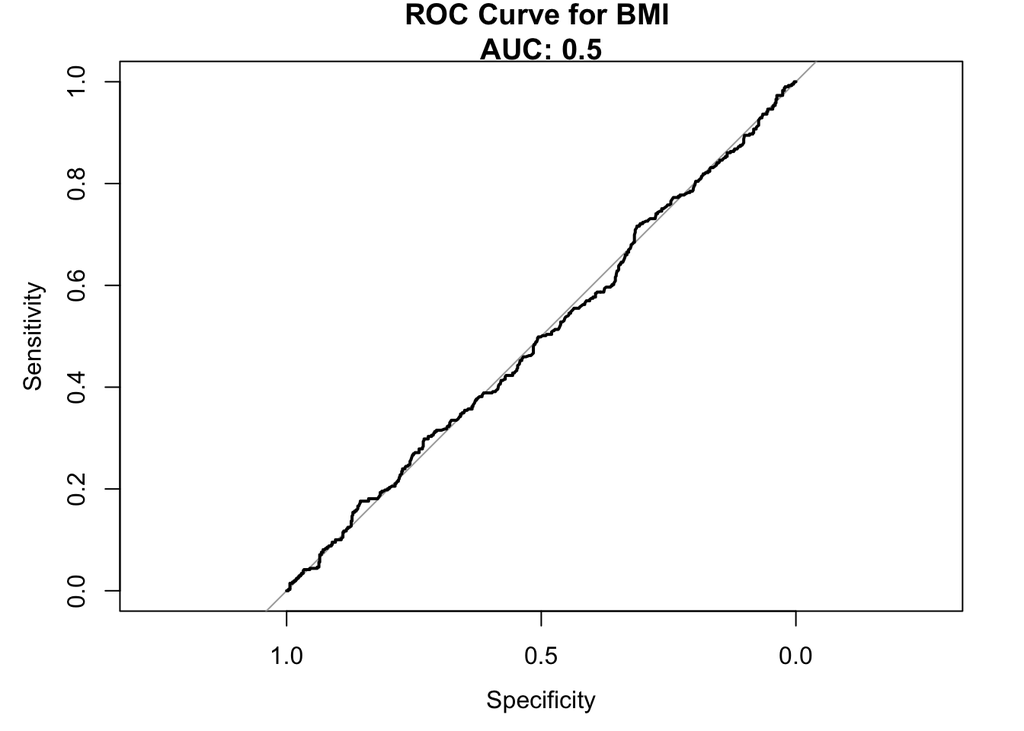

```r
# Function to draw a ROC curve and calculate AUC
roc_function <- function(predicted_var, var_name) {
  roc_curve_var <- roc(df$Death, predicted_var, quiet = TRUE)
  auc_var <- auc(roc_curve_var)
  plot(roc_curve_var, main = paste("ROC Curve for", var_name, "\nAUC:", round(auc_var, 2)))
  return(list(auc = auc_var, var_name = var_name))
}

# Apply the function to all numeric columns
roc_results <- lapply(names(df)[sapply(df, is.numeric)], function(var_name) {
  roc_function(df[[var_name]], var_name)
})
```

Самое большое значение AUC = 0.93 для показателя FOUR, или балла по шкале комы FOUR при поступлении